# Simulation of Residual Confounding by SES

DAG‑informed simulation + NHANES scaffold

Author

Published

August 14, 2025

## Background

- SES is often modeled **linearly** or as **quintiles**.
- True relationships may be **non-linear** (saturation, thresholds, U‑shapes).
- **Selection** (healthy-volunteer bias) further **attenuates** SES.

## Methods (Simulation)

- Latent SES* → mediators (BMI, SBP, smoking) → outcome (binary).
- Non-linear SES*→mediator functions + direct SES*→Y.
- Biobank-like selection; noisy/coarsened SES proxies.
- Compare **typical models** vs **splines + g-computation**.
- SES attribution via **causal R^2** and Shapley shares.

## Key Numbers

```
- Population N: **200,000**
- Selected N: **9,851**
- Prevalence (pop → sel): **5.99% → 3.57%**
- McFadden R^2 (linear vs over-adj): **0.011 → 0.055**
- Causal R^2 (pop → sel, oracle/proxy): **0.0052 → 0.0159/0.0015**
```

## Dose–Response

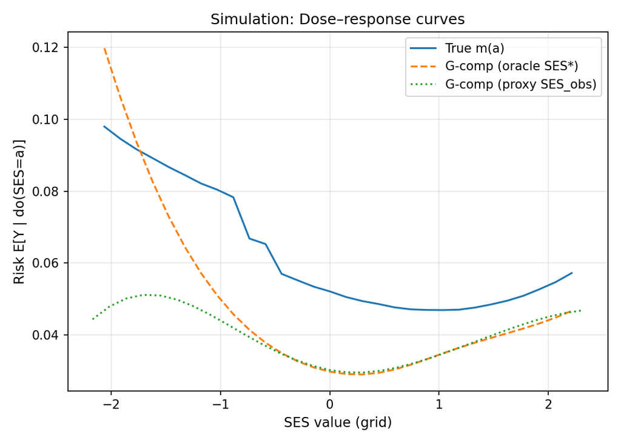

## NHANES Scaffold (Real Data)

- Harmonizes PIR/education, BMI, SBP, smoking, CVD.
- Survey-weighted fits vs. biobank-like selection.
- Dose–response via spline + g-computation.

> Not distributed here; runs if you provide local XPTs.

## Reproducibility

- Parameterized notebook + **Makefile**.
- **Inline tests** and session info with code hashes.
- Artifacts saved under `artifacts/`.
- **Quarto** builds abstract (PDF) and poster (HTML).